# Final Project: Visualizing Coronavirus Data

Name: Kylie Stearns & Sal Figueroa

2025-05-22

```r
#### Load necessary library ####
packages <- c("knitr", "kableExtra", "magrittr", "readr", "geosphere")

install_me <- packages[!(packages %in% installed.packages()[, "Package"])]
if (length(install_me)) install.packages(install_me)

library(knitr)
library(magrittr)
library(readr)
library(geosphere)
```

```r
library(ggplot2)
library(treemapify)
library(tidyverse)
library(ggfittext)
library(scales)
library(dplyr)
library(data.table)
library(ggrepel)
library(scales)
library(stringr)
library(leaflet)
library(kableExtra)
library(gridExtra)
#library(cowplot)

knitr::opts_chunk$set(echo=TRUE)
```

## Github Repository

*Repository holds all related files to Project*

[github: Figgs0bit-Final Project (https://github.com/Figgs0bit/CSIT165-CovidGroupProj-2)](https://github.com/Figgs0bit/CSIT165-CovidGroupProj-2)

## Required data sets

*Data for 2019 Novel Coronavirus is operated by the John Hopkins University Center for Systems Science and Engineering (JHU CSSE). Data includes daily time series CSV summary tables, including confirmations, recoveries, and deaths. Country/region are countries/regions hat conform to World Health Organization (WHO). Lat and Long refer to coordinates references for the user. Date fields are stored in MM/DD/YYYY format.*

*For this project, we will use ALL of the data sets provided in this GitHub repository. These include global data sets for COVID-19 associated confirmations and deaths as well as COVID-19 data sets associated with confirmations and deaths for cities in the US.*

[2019 Novel Coronavirus COVID-19 (2019-nCoV) Data Repository by John Hopkins CSSE](https://github.com/CSSEGISandData/COVID-19/tree/master/csse_covid_19_data/csse_covid_19_time_series)

*-time_series_covid19_deaths_global.csv*

*-time_series_covid19_deaths_US.csv*

*-time_series_covid19_confirmed_global.csv*

*-time_series_covid19_confirmed_US.csv*

### Data Load

```r
DL_day <- 22
cat("Lab represents data download May", DL_day,"th, 2025")
```

```
## Lab represents data download May 22 th, 2025
```

```r
#time_series_covid19_confirmed_global.csv, Rows-289 and Cols-1147.
confirmed_global <- as.data.frame(read.csv("https://raw.githubusercontent.com/CSSEGISandData/COVID-19/refs/heads/master/csse_covid_19_data/csse_covid_19_time_series/time_series_covid19_confirmed_global.csv"))

#time_series_covid19_deaths_global.csv, Rows-289 and Cols-1147.
deaths_global <- as.data.frame(read.csv("https://raw.githubusercontent.com/CSSEGISandData/COVID-19/refs/heads/master/csse_covid_19_data/csse_covid_19_time_series/time_series_covid19_deaths_global.csv"))

#time_series_covid19_deaths_global.csv, Rows-3342 and Cols-1155 Has population
deaths_US <- as.data.frame(read.csv("https://raw.githubusercontent.com/CSSEGISandData/COVID-19/refs/heads/master/csse_covid_19_data/csse_covid_19_time_series/time_series_covid19_deaths_US.csv"))

#loads the population column from data frame Deaths_US
Population <- deaths_US[12]

#time_series_covid19_confirmed_global.csv, Rows-3342 and Cols-1154
confirmed_US <- as.data.frame(read.csv("https://raw.githubusercontent.com/CSSEGISandData/COVID-19/refs/heads/master/csse_covid_19_data/csse_covid_19_time_series/time_series_covid19_confirmed_US.csv"))

#Adds Population column to confirmed_us dataframe.
confirmed_US <- cbind(Population, confirmed_US)

#Serve as data frame length and width variables
#Moslty used on loop conditions
USrowmax <- nrow(confirmed_US[,]) #limit Qty of Rows 3342
UScolmax <- ncol(confirmed_US[,]) #limit Qty of Cols 1155
GloRowmax <- nrow(confirmed_global[,]) #limit Qty of Rows 289
GloColmax <- ncol(confirmed_global[,]) #limit Qty of Cols 1147
#loads column headers in data.frame
GNameCol <- as.data.frame(colnames(confirmed_global))
DNameCol <- as.data.frame(colnames(deaths_global))
```

## Instructions

*Before beginning your objectives in your final document, please state which day you downloaded the data sets on for analysis. The objectives for this lab will cumulatively cover many subjects discussed in this course and will also contain an objective for manipulating strings.* *The surgeon general for the United States recently created a new data science initiative, CSIT-165, that uses data science to characterize pandemic diseases. CSIT-165 disseminates data driven analyses to state governors. You are a data scientist for CSIT-165 and it is up to you and you alone to manipulate and visualize COVID-19 data for disease control.*

## Objectives

*This project will encompass many of the lessons we have learned throughout the course, including interactive visualizations. RMarkdown files must be written such that each time you render the document it will download the necessary data sets for analysis. Please render the RMarkdown file the day it is due to reflect the most recent data sets. With this added functionality, your code must be able to analyze the datasets regardless of the date you render your document. Unlike others projects in the past, you will have the ability to solve these problems using any method you choose. Be careful, however, with the methods you use as you will be graded on the appropriateness of your solution and how well you execute your desired algorithm. If there appears to be a logic fail in how you executed your code, you will be penalized. This is an opportunity to really showcase your new found skills in data science with R!*

## Objective 1 *- Global Map*

*You are tasked to create a world map to gain an appreciation for where the most occurrences of COVID-19 confirmations and deaths are located.*

*Create this map using leaflet for the most recent date as shown below. For this map, sum the confirmations and deaths of provinces into one value to depict the total number for the country they belong to. When creating a marker for each country in the map, calculate lat and long as the mean values for the provinces that make up each country.*

*Customize the map to reflect the differences in magnitude for confirmations and deaths. In the example map below, circle markers that are blue represent low values, gray represents neutral values, and red represents high values. Low, middle, and high values were categorized to aesthetically map the markers based on their probabilistic distribution using the quartile function. You may use any method you like so that it is logical and allows visualization of value intensity. As well, customize the map to include hover labels that indicate country names and popup labels to show the value of confirmations and deaths for that country. For extra help using leaflet, consult this website along with the information provided in your textbooks.*

```r
#Initiates new dataframe var, serves as a Buffer variable for downloaded Data Frames.
confirmed <- confirmed_global
deaths <- deaths_global

#Pulls out the most recent date column of data for confirmed
LastDateCol <- tail(names(confirmed), 1)


#dplyr pipe using confirmed data frame then loads to ob1Data.
ob1Data <- confirmed %>%
    #Groups the data by the Country.Region column.
    group_by(Country.Region) %>%
    #Sums the confirmed cases for the latest date across all rows for that country.
    #Sym() converts string from LastDateCol to a column using tidy.
    summarise(Total_Confirmed = sum(!!sym(LastDateCol), na.rm = TRUE),
    #Calculates the average (mean) latitude (avgLAT) and longitude (avgLONG) for each country.
    #Then these averages to be used to plot a country on a OB1map.
    avgLAT = mean(Lat, na.rm = TRUE), avgLONG = mean(Long, na.rm = TRUE)) %>%
    #left join with deaths data frame, adds death totals to the summary table.
    left_join(deaths %>%
    #Groups deaths by country
    group_by(Country.Region) %>%
    #creates Total_Deaths column, Summarises the deaths for latest date per country.
    summarise(Total_Deaths = sum(!!sym(LastDateCol), na.rm = TRUE)), by = "Country.Region")


#This code adds two new columns to ob1Data, placing each row into a "Low", "Medium", or "High" category for both total confirmed cases and total deaths, using quartiles as the boundaries.
#dplyr pipe modifies ob1Data and stores back into ob1Data.
ob1Data <- ob1Data %>%
    #mutate() function adds column Confirmed_Category to data frame taken from cut() applied to Total_Confirmed.
    mutate(Confirmed_Category = cut(Total_Confirmed,
    #break points for cut() function quantile() computes the break points based Total_Confirmed distribution.
    breaks = quantile(Total_Confirmed,
    #Points quantile() to use 0,25,50,100% ratios in decimal form. This creates (3) intervals.
    probs = c(0, 0.25, 0.5, 1),
    #Ignore (NA) values in data.
    na.rm = TRUE),
    #Low(bottom 25%),Medium(middle 50%), High(top 25%).
    labels = c("Low", "Medium", "High"),
    #Include lowest value of Total_Confirmed in the "Low" interval.
    include.lowest = TRUE),
    #Adds DeathCol column, cut() function divides Total_Deaths vector.
    DeathCol = cut(Total_Deaths,
    #Breaks, quantile() function splits along percentages previously defined.
    #distributes each country/row Total_Deaths to (Low, Medium, High) categories.
    breaks = quantile(Total_Deaths,
    #Points quantile() to use 0,25,50,100% ratios in decimal form. This creates (3) intervals.
    probs = c(0, 0.25, 0.5, 1),
    #Ignore (NA) values in data.
    na.rm = TRUE),
    #Low(bottom 25%),Medium(middle 50%), High(top 25%).
    labels = c("Low", "Medium", "High"),
    #Include lowest value of Total_Confirmed in the "Low" interval.
    include.lowest = TRUE))


#Defines colors for low, med, high categories for Confirmed and Deaths
PlotColorConfirmed <- colorFactor(c("black", "lightblue", "blue"), levels = c("Low", "Medium", "High"))
PlotColorDeaths <- colorFactor(c("yellow", "orange", "red"), levels = c("Low", "Medium", "High"))


#Create/Initializes the leaflet OB1map
OB1map <- leaflet(ob1Data) %>%
    #Adds the default OpenStreet OB1map tile layer as background: provides roads, countries for all points.
    addTiles() %>%

    #Adds circle markers for confirmed cases via ~avgLONG, ~avgLAT variable.
    #Each point is the average longitude/latitude per country.
    addCircleMarkers(~avgLONG, ~avgLAT,
    #country name pop's up when you hover over point.
    label = ~paste(Country.Region),
    #An additional info bubble appears when point is clicked for total confirmed/deaths.
    popup = ~paste0("<strong>", Country.Region, "</strong><br>", "Total Confirmed: ", Total_Confirmed, "<br>", "Total Deaths: ", Total_Deaths),
    #Colors the marker according to each country's confirmed cases category so Low, Medium, High.
    color = ~PlotColorConfirmed(Confirmed_Category),
    #Sets each marker's size proportional to total confirmed cases. It re-scales as you zoom in.
    #Lager number in the denominator creates a smaller radius when zoomed out.
    #Use square root function to drive the down the numerator and over all value.
    radius = ~sqrt(Total_Confirmed) / 200, #
    #assigns points to Confirmed group.
    group = "Confirmed") %>%


    #Similar to code for confirmed cases but serves to plot deaths.
    addCircleMarkers(~avgLONG, ~avgLAT, label = ~paste(Country.Region),
    popup = ~paste0("<strong>", Country.Region, "</strong><br>", "Total Confirmed: ", Total_Confirmed, "<br>", "Total Deaths: ", Total_Deaths),
    color = ~PlotColorDeaths(DeathCol),
    radius = ~sqrt(Total_Deaths) / 200,
    group = "Deaths") %>%


    #Allows user to toggle between Confirmed and Deaths points on OB1map.
    addLayersControl(overlayGroups = c("Confirmed", "Deaths"), options = layersControlOptions(collapsed = FALSE))

OB1map #Prints/dsiplays Interactive OB1map
```

[interactive chart not shown]

## Objective 2 *- Narrowing Down Hot Spots*

*Seeing the global map of COVID-19 cases results in the stark realization that some countries are more affected than others. In order to narrow down your studies, create a table using kable from knitr listing the top countries as far as confirmations and deaths (sum values for provinces of the same country into one value and show the country only). Now that we are using RMarkdown to create HTML files, we have much more options for how we display our table. For reference on how to customize tables using knitr, visit this website. Consult the table below for an example of a customized table ranking cases by country. While it is not required to replicate this table exactly, it would be a fantastic challenge to show off your knitr prowess.*

```r
#Assigns the data frames confirmed_global and deaths_global to buffer variables.
confirmed <- confirmed_global
deaths <- deaths_global

#Tail() gets data from last column in data-frames, this column represents the most recent date.
confirmedLastDay <- tail(names(confirmed), 1)
deathsLastDay <- tail(names(deaths), 1)


#Initiates ob2DataConfirmed and loads the summed values in each column For each group (country/region).
#creates two columns (contry.region, total_confirmed).
ob2DataConfirmed <- confirmed %>%
  group_by(Country.Region) %>%
  summarise(Total_Confirmed = sum(!!sym(confirmedLastDay), na.rm = TRUE))

#Same as above, but for deaths.
ob2DataDeaths <- deaths %>%
  group_by(Country.Region) %>%
  summarise(Total_Deaths = sum(!!sym(deathsLastDay), na.rm = TRUE))

#Joins the two previous data frames will be used for final interactive table.
ob2DataCountry <- full_join(ob2DataConfirmed, ob2DataDeaths, by = "Country.Region") %>%
  arrange(desc(Total_Confirmed)) %>%
  mutate(Rank = row_number())

#Moves the Rank column to be the first column in the data frame.
ob2DataCountry <- ob2DataCountry %>% select(Rank, everything())

#creates interactive table that allows use to scroll through.
ob2DataCountry %>%
  #Kable converts the dataframes into an HTML table, the column names are listed.
  kable("html", col.names = c("Rank", "Country", "Total Confirmations", "Total Deaths")) %>%
  #Controls the features and asthetic of the table.
  kable_styling(bootstrap_options = c("striped", "hover", "condensed"), full_width = FALSE, fixed_thead = TRUE) %>%
  #adds thick, black border below table.
  row_spec(0, extra_css = "border-bottom: 2px solid black;") %>%
  #Controls the size of the scroll area
  scroll_box(height = "475px", width = "100%") %>%
  #Controls the aesthetic for each column
  column_spec(1, bold = TRUE, color = "black", background = "white") %>%
  column_spec(2, bold = TRUE, color = "black", background = "white") %>%
  column_spec(3, bold = TRUE, color = "black", background = "white") %>%
  column_spec(4, bold = TRUE, color = "black", background = "white") %>%

  #adds the header/title at the top of chart.
  add_header_above(c("COVID-19: Table of Top Countries" = 4))
```

| COVID-19: Table of Top Countries Rank | COVID-19: Table of Top Countries Country | COVID-19: Table of Top Countries Total Confirmations | COVID-19: Table of Top Countries Total Deaths |
| --- | --- | --- | --- |
| 1 | US | 103802702 | 1123836 |
| 2 | India | 44690738 | 530779 |
| 3 | France | 39866718 | 166176 |
| 4 | Germany | 38249060 | 168935 |
| 5 | Brazil | 37076053 | 699276 |
| 6 | Japan | 33320438 | 72997 |
| 7 | Korea, South | 30615522 | 34093 |
| 8 | Italy | 25603510 | 188322 |
| 9 | United Kingdom | 24658705 | 220721 |
| 10 | Russia | 22075858 | 388478 |
| 11 | Turkey | 17042722 | 101492 |
| 12 | Spain | 13770429 | 119479 |
| 13 | Vietnam | 11526994 | 43186 |
| 14 | Australia | 11399460 | 19574 |
| 15 | Argentina | 10044957 | 130472 |
| 16 | Taiwan* | 9970937 | 17672 |
| 17 | Netherlands | 8712835 | 23705 |
| 18 | Iran | 7572311 | 144933 |
| 19 | Mexico | 7483444 | 333188 |
| 20 | Indonesia | 6738225 | 160941 |
| 21 | Poland | 6444960 | 119010 |
| 22 | Colombia | 6359093 | 142339 |
| 23 | Austria | 5961143 | 21970 |
| 24 | Ukraine | 5711929 | 119283 |
| 25 | Portugal | 5570473 | 26266 |
| 26 | Greece | 5548487 | 34779 |
| 27 | Chile | 5192286 | 64273 |
| 28 | Malaysia | 5044718 | 36967 |
| 29 | China | 4903524 | 101056 |
| 30 | Israel | 4803824 | 12329 |

[output cut: 171 more lines]

## Objective 3 *- Zooming Into Our State*

*After reading the top tables, you are stunned! The US overtakes every other country in terms of COVID-19 confirmations. As such, you are concerned about the state you live in and would like to understand how COVID-19 events have shaped the trajectory of the disease. Create two scatter plots to gain a better understanding. The first scatter plot should be California’s trajectory for confirmations. The second scatter plot should show California’s top three city trajectories for confirmations. You are interested in studying how the vaccine affected the number of confirmations. The Moderna vaccine was first available as an emergency use authorized (EUA) vaccine and required two shots spaced six weeks apart. Indicate on the plots the day the second dosage was given to those that received the first dosage the day Moderna was EUA (January 29th, 2021). As a diligent scientist that knows that new COVID variants have mutations in the spike protein (the region that the vaccine was developed for), you also want to study how confirmation rates change as new variants become the dominant infectious strain. Indicate on the plots when the delta and omicron variants became the dominant strain in California (May 11th, 2021 and November 26th, 2021 respectively). In the example below, the function plot_grid from the R package cowplot was to organize the graphs into a grid to more easily compare statewide vs top city plots.*

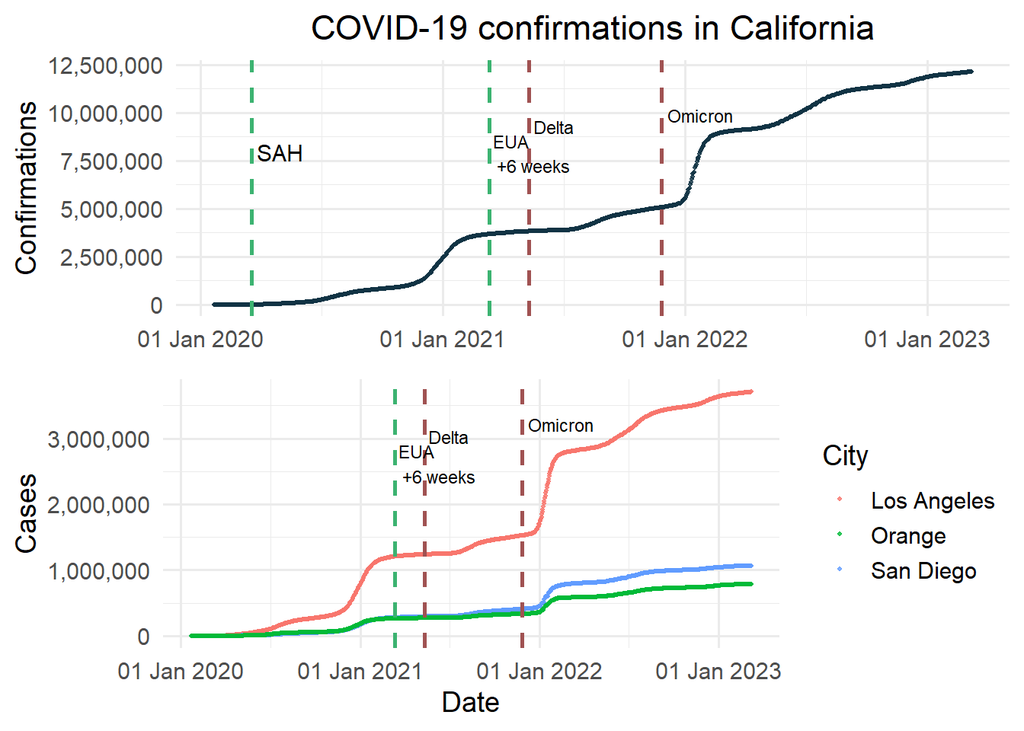

```r
#Load the US confirmed US dataframe into local variable to serve as a buffer.
covid_us <- confirmed_US

#initiates and loads a numeric vector with all of the counties in CA.
CAdata <- covid_us %>%
  filter(Province_State == "California") %>%
  select(starts_with("X")) %>%
  colSums() %>%
  as.numeric()

#initiates and loads vector with column dates, converts to date format.
dataDates <- colnames(covid_us)[grepl("^X", colnames(covid_us))]
dataDates <- as.Date(sub("X", "", dataDates), format="%m.%d.%y")
#Converts to data frame of dates and m/d/y date form.
stateData <- data.frame(Date = dataDates, Confirmations = CAdata)

#initiates and loads data frame with all of CA county data.
countyCA <- covid_us %>%
  filter(Province_State == "California")

#Finds loads the latest date from countyCA datafile
latest_date <- tail(colnames(countyCA)[grepl("^X", colnames(countyCA))], 1)

#Initiates and loads new dataframe with data columns of top three CA counties
top3 <- countyCA %>%
  mutate(Total = .data[[latest_date]]) %>%
  arrange(desc(Total)) %>%
  #slice selects the first three rows of data frame
  slice(1:3) %>%
  #Admin2 is the column that holds the county names
  select(Admin2, starts_with("X"))

#Initiates and loads numeric vector, Transforms wide format to long format.
cityData <- top3 %>%
  tidyr::pivot_longer(cols = starts_with("X"),names_to = "Date", values_to = "Cases") %>%
  mutate(Date = as.Date(sub("X", "", Date), format="%m.%d.%y"), City = Admin2)


#Defines COVID-19 event dates variables to plot vertical lines.
SAH <- as.Date("2020-03-19")
EUA <- as.Date("2021-01-29")
EUA2ndDose <- EUA + 42
Delta <- as.Date("2021-05-11")
Omicron <- as.Date("2021-11-26")


#Creates a scatter plot of CA's total confirmed cases by date.
ob3Scatter1 <- ggplot(stateData, aes(x=Date, y=Confirmations)) +
  #Adds the points to plot and controls the size, color of said points.
  geom_point(color="#113344", size=0.75, alpha=0.8) +
  #Sets the plot title and axis labels.
  labs(title="COVID-19 confirmations in California", y="Confirmations", x=NULL) +
  #controls the type and asthetic of the x, y axis.
  scale_x_date(date_labels = "%d %b %Y") +
  scale_y_continuous(labels=comma) +
  #Applies minimal styling and center plot title.
  theme_minimal(base_size = 14) +
  theme(plot.title=element_text(hjust=0.5)) +
  #Adds dashed vertical lines for major pandemic events.
  #asthetic of the for lines can be controlled here.
  geom_vline(xintercept=SAH, linetype="dashed", color="#3CB371", size=1) +
  geom_vline(xintercept=EUA2ndDose, linetype="dashed", color="#3CB371", size=1) +
  geom_vline(xintercept=Delta, linetype="dashed", color="#A05252", size=1) +
  geom_vline(xintercept=Omicron, linetype="dashed", color="#A05252", size=1) +
  #Add note with an event labeled to previous vertical line.
  annotate("text", x=SAH, y=max(stateData$Confirmations)*0.7, label="SAH", hjust=-0.1, vjust=1.1, size=4) +
  annotate("text", x=EUA2ndDose, y=max(stateData$Confirmations)*0.75, label="EUA\n+6 weeks", hjust=-0.1, vjust=1.1, size=3) +
  annotate("text", x=Delta, y=max(stateData$Confirmations)*0.8, label="Delta", hjust=-0.1, vjust=1.1, size=3) +
  annotate("text", x=Omicron, y=max(stateData$Confirmations)*0.85, label="Omicron", hjust=-0.1, vjust=1.1, size=3)
#Same as above but this scatter is of confirmed cases by date for top three counties.
ob3Scatter2 <- ggplot(cityData, aes(x=Date, y=Cases, color=City)) +
  geom_point(size=0.75, alpha=0.8) +
  labs(y="Cases", x="Date") +
  scale_x_date(date_labels = "%d %b %Y") +
  scale_y_continuous(labels=comma) +
  theme_minimal(base_size = 14) +
  theme(legend.position="right") +
  geom_vline(xintercept=EUA2ndDose, linetype="dashed", color="#3CB371", size=1) +
  geom_vline(xintercept=Delta, linetype="dashed", color="#A05252", size=1) +
  geom_vline(xintercept=Omicron, linetype="dashed", color="#A05252", size=1) +
  annotate("text", x=EUA2ndDose, y=max(cityData$Cases)*0.8, label="EUA\n+6 weeks", hjust=-0.1, vjust=1.1, size=3) +
  annotate("text", x=Delta, y=max(cityData$Cases)*0.85, label="Delta", hjust=-0.1, vjust=1.1, size=3) +
  annotate("text", x=Omicron, y=max(cityData$Cases)*0.9, label="Omicron", hjust=-0.1, vjust=1.1, size=3)

#Display both plots stacked vertically
grid.arrange(ob3Scatter1, ob3Scatter2, ncol=1)
```

## Objective 4 *- Digging Deeper*

*Although these plots do not tell the whole story, they are great for helping us determine where to look. Different cities may have different populations, population densities, cultural discrepancies, compliance, and city regulations to name a few. We will explore the role of population on these metrics using visualizations. Arrange two scatter plots using cowplot’s plot_grid to show the relationship between population and confirmed counts as well as death counts and confirmed counts. You will need to use a log transform on all variables to show such a relationship. Please consult the example below for an idea of what this may look like. From these graphs we can see that population greatly affects confirmations and deaths. This coincides with our plots above as the population of Los Angeles is 301% greater than San Diego’s population and 406% greater than Riverside’s population!*

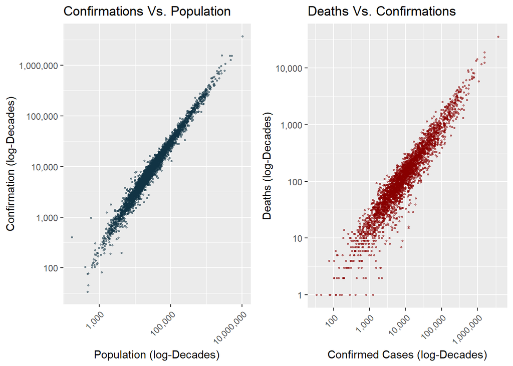

```r
#Load the US confirmed and deaths dataframes into local variables to serve as a buffer.
confirmed <- confirmed_US
deaths <- deaths_US

#Finds and assigns the column header of the last, most recent column date.
confirmedLastDateCol <- tail(grep("^X", names(confirmed), value = TRUE), 1)

#Initializes and loads a new dataframe with 5 columns listed
ob4confirmedData <- confirmed %>%
    select(UID, Admin2, Province_State, Population, Confirmed = all_of(confirmedLastDateCol))

#similar as above, but for US deaths data.
deathsLastDateCol <- tail(grep("^X", names(deaths), value = TRUE), 1)

#Creates new dataframe from deaths, selecting the columns listed.
deathsUID <- deaths %>%
    select(UID, Deaths = all_of(deathsLastDateCol))

#Using pipes, Joins the ob4confirmedData, deathsUID data frames.
merged <- ob4confirmedData %>%
    left_join(deathsUID, by = "UID") %>%
    #Filter Keeps only rows where population, confirmed, and deaths are all present and greater than zero.
    #With this line, chunk keeps producing warnings.
    filter(!is.na(Population), Population > 0, Confirmed > 0, Deaths > 0)


#Creates a scatter plot using merged data, Confirmed cases and population as x, y variables.
ob4Scatter1 <- ggplot(merged, aes(x = Population, y = Confirmed)) +
    #adds scatter points and controls it's aesthetic.
    geom_point(color = "#113344", alpha = 0.5, size = .5) +
    #Sets the x, y axis type as logarithmic with intervals in a log decade. Also initiates comma's.
    scale_x_log10(labels = comma) +
    scale_y_log10(labels = comma) +
    #Sets plot title and x,y axis labels.
    labs(title = "Confirmations Vs. Population", x = "Population (log-Decades)", y = "Confirmation (log-Decades)") +
    #hjust, right justifies the axis labels and rotates the values 45 degrees.
    theme(axis.text.x = element_text(angle = 45, hjust = 1))

#2nd scatter plot compares deaths vs Confirmations.
ob4Scatter2 <- ggplot(merged, aes(x = Confirmed, y = Deaths)) +
    geom_point(color = "#880000", alpha = 0.5, size = .5) +
    scale_x_log10(labels = comma) +
    scale_y_log10(labels = comma) +
    labs(title = "Deaths Vs. Confirmations", x = "Confirmed Cases (log-Decades)", y = "Deaths (log-Decades)") +
    theme(axis.text.x = element_text(angle = 45, hjust = 1))

#Arranges the two plots side by side in a single row.
grid.arrange(ob4Scatter1, ob4Scatter2, nrow = 1)
```

## Conclusion *synopsis*

*Kylie Stearns*

*This project brought together all the major skills learned this semester—data wrangling, visualization, and clear interpretation. We connected real-world patterns to meaningful questions and practiced both technical and narrative clarity in our analysis.*

*Sal Figueroa*

*Who gets the money?*

## GitHub Log

```bash
git log --pretty=format:"%nSubject: %s%nAuthor: %aN%nDate: %aD%nBody: %b"
```

```
##
## Subject: Manually added Kylies code for ob2 and ob4. ob1,ob2, ob4 are all fully knitting and code ref. notes are added. Ob3 is not done.
## Author: Sal - Figgs0bit
## Date: Wed, 21 May 2025 20:28:01 -0700
## Body:
##
## Subject: OB3 almost working, need to adjust point sizes and x axis labels.
## Author: Sal - Figgs0bit
## Date: Wed, 21 May 2025 09:33:36 -0700
## Body:
##
## Subject: OB1 - Properly working
## Author: Sal - Figgs0bit
## Date: Tue, 20 May 2025 16:14:15 -0700
## Body:
##
## Subject: Merge branch 'main' of github.com:Figgs0bit/CSIT165-CovidGroupProj-2
## Author: Sal - Figgs0bit
## Date: Thu, 15 May 2025 14:03:10 -0700
## Body:
##
## Subject: Report Text finished, Working on Obj1
## Author: Sal - Figgs0bit
## Date: Thu, 15 May 2025 14:02:54 -0700
## Body:
##
## Subject: Add files via upload
## Author: Figgs0bit
## Date: Thu, 15 May 2025 13:22:34 -0700
## Body:
##
## Subject: First Commit, text being adjusted. No code chunks
## Author: Sal - Figgs0bit
## Date: Thu, 15 May 2025 12:11:53 -0700
## Body:
##
## Subject: Initial commit
## Author: Figgs0bit
## Date: Wed, 14 May 2025 21:16:49 -0700
## Body:
```